# p8105_hw5_yc3577

Firstly, we load in the data files by using `list.files()` with input of `path`, `pattern`, and `full.names`. Then we will use `map_dfr`to map the function of `read_csv()` that load in several csv documents with repetition. We should also use `mutate()` to help combine the csv documents together with corresponded `subject_id` and `control_arm`. By using `str_extract()` function, we can use regex to extract the according values we want. After getting the combined dataframe, we need to clean it by using `pivot_longer()` to collect the week 1 to week 8 together into one week column. Then for later graphing, we need to recode the week_1 to 1 by using `mutate()` and `recode()`.

```r
file_names =
  list.files(path = './data',
             pattern = '.csv',
             full.names = TRUE)
file_names
```

```
##  [1] "./data/con_01.csv" "./data/con_02.csv" "./data/con_03.csv"
##  [4] "./data/con_04.csv" "./data/con_05.csv" "./data/con_06.csv"
##  [7] "./data/con_07.csv" "./data/con_08.csv" "./data/con_09.csv"
## [10] "./data/con_10.csv" "./data/exp_01.csv" "./data/exp_02.csv"
## [13] "./data/exp_03.csv" "./data/exp_04.csv" "./data/exp_05.csv"
## [16] "./data/exp_06.csv" "./data/exp_07.csv" "./data/exp_08.csv"
## [19] "./data/exp_09.csv" "./data/exp_10.csv"
```

```r
df =
  file_names |>
      map_dfr(~read_csv(.x)  |>
             mutate(subject_id = str_extract(.x, '\\d+'),
                    control_arm = str_extract(.x, 'con|exp')))
df
```

```
## # A tibble: 20 × 10
##    week_1 week_2 week_3 week_4 week_5 week_6 week_7 week_8 subject_id
##     <dbl>  <dbl>  <dbl>  <dbl>  <dbl>  <dbl>  <dbl>  <dbl> <chr>
##  1   0.2   -1.31   0.66   1.96   0.23   1.09   0.05   1.94 01
##  2   1.13  -0.88   1.07   0.17  -0.83  -0.31   1.58   0.44 02
##  3   1.77   3.11   2.22   3.26   3.31   0.89   1.88   1.01 03
##  4   1.04   3.66   1.22   2.33   1.47   2.7    1.87   1.66 04
##  5   0.47  -0.58  -0.09  -1.37  -0.32  -2.17   0.45   0.48 05
##  6   2.37   2.5    1.59  -0.16   2.08   3.07   0.78   2.35 06
##  7   0.03   1.21   1.13   0.64   0.49  -0.12  -0.07   0.46 07
##  8  -0.08   1.42   0.09   0.36   1.18  -1.16   0.33  -0.44 08
##  9   0.08   1.24   1.44   0.41   0.95   2.75   0.3    0.03 09
## 10   2.14   1.15   2.52   3.44   4.26   0.97   2.73  -0.53 10
## 11   3.05   3.67   4.84   5.8    6.33   5.46   6.38   5.91 01
## 12  -0.84   2.63   1.64   2.58   1.24   2.32   3.11   3.78 02
## 13   2.15   2.08   1.82   2.84   3.36   3.61   3.37   3.74 03
## 14  -0.62   2.54   3.78   2.73   4.49   5.82   6      6.49 04
## 15   0.7    3.33   5.34   5.57   6.9    6.66   6.24   6.95 05
## 16   3.73   4.08   5.4    6.41   4.87   6.09   7.66   5.83 06
## 17   1.18   2.35   1.23   1.17   2.02   1.61   3.13   4.88 07
## 18   1.37   1.43   1.84   3.6    3.8    4.72   4.68   5.7  08
## 19  -0.4    1.08   2.66   2.7    2.8    2.64   3.51   3.27 09
## 20   1.09   2.8    2.8    4.3    2.25   6.57   6.09   4.64 10
## # ℹ 1 more variable: control_arm <chr>
```

```r
cleaned_df =
  df |>
  pivot_longer(
    week_1:week_8,
    names_to = 'week',
    values_to = 'observation'
  ) |>
    mutate(
    week = recode(week,
                  'week_1' = '1',
                  'week_2' = '2',
                  'week_3' = '3',
                  'week_4' = '4',
                  'week_5' = '5',
                  'week_6' = '6',
                  'week_7' = '7',
                  'week_8' = '8'
                  )
  )
cleaned_df
```

```
## # A tibble: 160 × 4
##    subject_id control_arm week  observation
##    <chr>      <chr>       <chr>       <dbl>
##  1 01         con         1            0.2
##  2 01         con         2           -1.31
##  3 01         con         3            0.66
##  4 01         con         4            1.96
##  5 01         con         5            0.23
##  6 01         con         6            1.09
##  7 01         con         7            0.05
##  8 01         con         8            1.94
##  9 02         con         1            1.13
## 10 02         con         2           -0.88
## # ℹ 150 more rows
```

Make a spaghetti plot showing observations on each subject over time, and comment on differences between groups.

After we get the cleaned table, we can plot the observations with `ggplot()` and we need to group by the subject_id and make color differences according to control_arm. Then we need to add `facet_wrap(~control_arm)` to wrap the control and experimental group separately for comparison, and we add `geom_line()` and `geom_point()` for visualisation and add title and axis name with `labs()`.

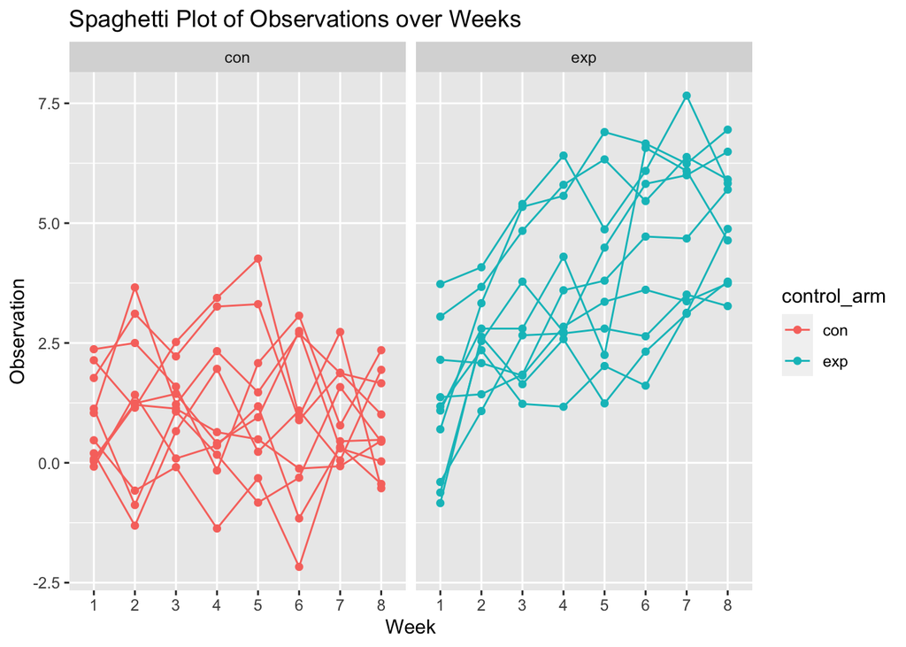

```r
spa_plot =
  ggplot(cleaned_df,
         aes(x = week,
             y = observation,
             group = subject_id,
             color = control_arm)) +
  facet_wrap(~control_arm) +
  geom_line() +
  geom_point() +
  labs(title = 'Spaghetti Plot of Observations over Weeks',
       x = 'Week',
       y = 'Observation')

spa_plot
```

From the graph, the majority of experimental group has relative higher values of observation over 8 weeks than those of the control group. Though, in each group, there is variation during 8 weeks, while the trend of experimental group is upward, and the control group is flatter. During the 1st week, the control group has an observation value around 0 to 2.5 and goes to near 4.3 at a highest value and goes to near -2.5 at the lowest value during week 5 and week 6, and finally get to stable between 0 to 2.5 at final week. Therefore, the trend for control group is flat. During the 1st week, the experimental group has a relative lower start from -1 to 3.75, and it increases while fluctuating and goes up to 7.5 in week 7 and get to the final value around 3 to 6.785. Moreover, the experimental group seems to have a larger variation and fluctuation range. However the overall trend is clear that the control group’s observation values fluctuate around a smaller range, and the experimental group’s observation values increase through time and fluctuate in a larger range.

Problem 3

When designing an experiment or analysis, a common question is whether it is likely that a true effect will be detected – put differently, whether a false null hypothesis will be rejected. The probability that a false null hypothesis is rejected is referred to as power, and it depends on several factors, including: the sample size; the effect size; and the error variance. In this problem, you will conduct a simulation to explore power in a one-sample t-test.

First set the following design elements:

Fix n=30 Fix σ=5 Set μ=0 . Generate 5000 datasets from the model

x∼Normal[μ,σ]

For each dataset, save μ̂ and the p-value arising from a test of H:μ=0 using α=0.05 . Hint: to obtain the estimate and p-value, use broom::tidy to clean the output of t.test.

We will do a simulation function by using `function()` and setting sigma = 5, sample_size = 30. Then we will add t test with `t.test()` with `broom::tidy` to tidy the test results. Then we use a for loop to run the simulaiton 5000 times with input of mu = 0.

```r
set.seed(12345)

simulation = function(mu, sigma = 5, sample_size = 30) {

  data = rnorm(n = sample_size, mean = mu, sd = sigma)

  sim_data = tibble(
  mu_hat = mean(data),
  sigma_hat = sd(data)

  )

test =
  t.test(data, alternative = 'two.sided', conf.level = 0.95) |>
  broom::tidy()

}

output = vector("list", 5000)

for (i in 1:5000) {
  output[[i]] = simulation(mu = 0)
}

sim_datasets = bind_rows(output)
sim_datasets
```

```
## # A tibble: 5,000 × 8
##    estimate statistic p.value parameter conf.low conf.high method    alternative
##       <dbl>     <dbl>   <dbl>     <dbl>    <dbl>     <dbl> <chr>     <chr>
##  1   0.394     0.460   0.649         29   -1.36      2.15  One Samp… two.sided
##  2   1.56      1.33    0.195         29   -0.842     3.96  One Samp… two.sided
##  3   2.18      2.20    0.0363        29    0.149     4.21  One Samp… two.sided
##  4   0.126     0.134   0.895         29   -1.80      2.06  One Samp… two.sided
##  5  -0.278    -0.248   0.806         29   -2.56      2.01  One Samp… two.sided
##  6   0.0257    0.0281  0.978         29   -1.85      1.90  One Samp… two.sided
##  7   0.686     0.969   0.341         29   -0.762     2.13  One Samp… two.sided
##  8   0.280     0.302   0.765         29   -1.61      2.17  One Samp… two.sided
##  9   0.0198    0.0236  0.981         29   -1.70      1.74  One Samp… two.sided
## 10  -0.919    -1.13    0.269         29   -2.59      0.749 One Samp… two.sided
## # ℹ 4,990 more rows
```

Repeat the above for μ={1,2,3,4,5,6}

After we create the simulation function, we can use `expand_grid` for repetition by specifying input values of 0 to 6 and iteration times of 5000. Then we can use `mutate()` to use `map()` to map the function of `simulation` on the input of mu. Then we use `unnest()` to get our new repetition data.

```r
# Repeat the above simulation for u ={1,2,3,4,5,6}
repetition =
  expand_grid(
    mu = c(0,1,2,3,4,5,6),
    iter = 1:5000
  ) |>
  mutate(
    estimate_df = map(mu, ~simulation(.x))
  ) |>
  unnest(estimate_df)

repetition
```

```
## # A tibble: 35,000 × 10
##       mu  iter estimate statistic p.value parameter conf.low conf.high method
##    <dbl> <int>    <dbl>     <dbl>   <dbl>     <dbl>    <dbl>     <dbl> <chr>
##  1     0     1  -1.91     -2.37    0.0245        29   -3.56     -0.264 One Samp…
##  2     0     2   0.514     0.495   0.624         29   -1.61      2.64  One Samp…
##  3     0     3   0.509     0.495   0.624         29   -1.59      2.61  One Samp…
##  4     0     4  -0.198    -0.239   0.813         29   -1.89      1.50  One Samp…
##  5     0     5   1.01      1.23    0.228         29   -0.664     2.68  One Samp…
##  6     0     6   0.0546    0.0785  0.938         29   -1.37      1.48  One Samp…
##  7     0     7  -1.92     -2.53    0.0170        29   -3.48     -0.369 One Samp…
##  8     0     8  -1.26     -1.67    0.105         29   -2.80      0.280 One Samp…
##  9     0     9  -0.118    -0.137   0.892         29   -1.88      1.64  One Samp…
## 10     0    10  -0.528    -0.536   0.596         29   -2.54      1.49  One Samp…
## # ℹ 34,990 more rows
## # ℹ 1 more variable: alternative <chr>
```

Make a plot showing the proportion of times the null was rejected (the power of the test) on the y axis and the true value of μ on the x axis. Describe the association between effect size and power.

To make a power plot, we need to clean the repetition by using `group_by()` and `summarise()` to get our x and y and then use `ggplot()` to plot the graph. Then we add `geom_line()` and `geom_point()` and `geom_smooth()` for visualizations then finally add title and axis names with `labs()`.

```r
power_df =
  repetition |>
  group_by(mu) |>
  summarise(
    p_value = mean(p.value < 0.05),
    sample_size = n(),
    proportion = p_value/sample_size
  )
power_df
```

```
## # A tibble: 7 × 4
##      mu p_value sample_size proportion
##   <dbl>   <dbl>       <int>      <dbl>
## 1     0  0.0534        5000  0.0000107
## 2     1  0.183         5000  0.0000366
## 3     2  0.553         5000  0.000111
## 4     3  0.890         5000  0.000178
## 5     4  0.991         5000  0.000198
## 6     5  0.999         5000  0.000200
## 7     6  1             5000  0.0002
```

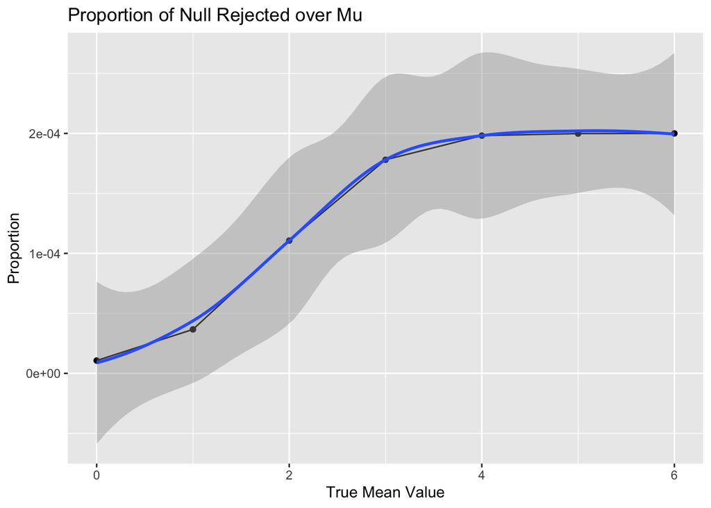

```r
power_plot =
  power_df |>
  ggplot(aes(x = mu, y = proportion)) +
  geom_line() +
  geom_point() +
  geom_smooth() +
  labs(
    title = 'Proportion of Null Rejected over Mu',
    x = 'True Mean Value',
    y = 'Proportion'
  )

power_plot
```

Comment: the power plot shows a relatively upward trending of proportion vs true mean that there may be a positive association, while when the true mean reaches 3, the proportion stays at the high value till true mean reaches 6.

Make a plot showing the average estimate of μ̂ on the y axis and the true value of μ on the x axis

To make a comparison plot, we need to clean the repetition by using `group_by()` and `summarise()` to get our x and y and then use `ggplot()` to plot the graph. Then we add `geom_line()` and `geom_point()` and `geom_smooth()` for visualizations then finally add title and axis names with `labs()`.

```r
esti_true_df =
  repetition |>
  group_by(mu) |>
  summarise(
    average_estimate = mean(estimate),
    true_mean = mu
  )
```

[output not shown]

```r
esti_true_df
```

```
## # A tibble: 35,000 × 3
## # Groups:   mu [7]
##       mu average_estimate true_mean
##    <dbl>            <dbl>     <dbl>
##  1     0           0.0141         0
##  2     0           0.0141         0
##  3     0           0.0141         0
##  4     0           0.0141         0
##  5     0           0.0141         0
##  6     0           0.0141         0
##  7     0           0.0141         0
##  8     0           0.0141         0
##  9     0           0.0141         0
## 10     0           0.0141         0
## # ℹ 34,990 more rows
```

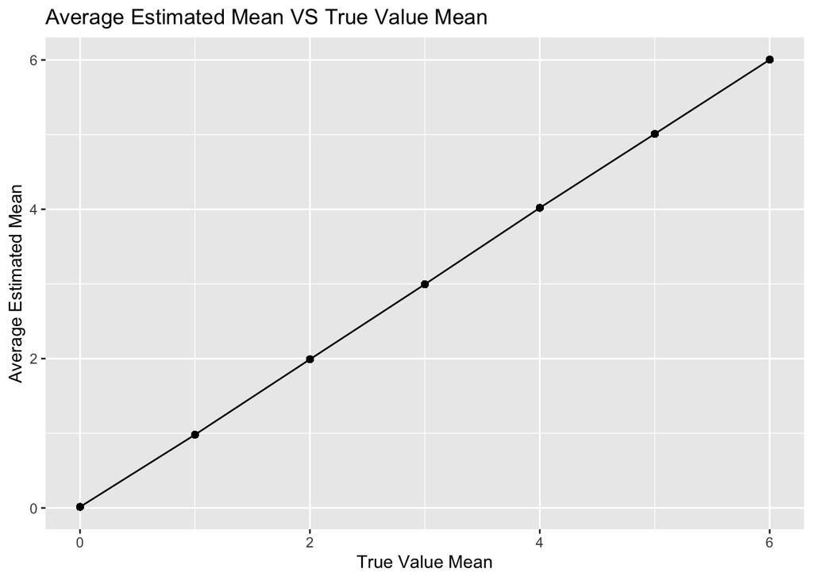

```r
esti_true_plot =
  esti_true_df |>
  ggplot(aes(x = true_mean, y = average_estimate)) +
  geom_point() +
  geom_line() +
  geom_smooth() +
  labs(
    title = 'Average Estimated Mean VS True Value Mean',
    x = 'True Value Mean',
    y = 'Average Estimated Mean'
  )

esti_true_plot
```

Comment: the esti true plot shows a strictly positive relationship between average estimated mean and true mean the higher the true mean, the higher the estimated mean.

Make a second plot (or overlay on the first) the average estimate of μ̂ only in samples for which the null was rejected on the y axis and the true value of μ on the x axis.

To make a comparison plot on null rejected, we need to clean the repetition by using `group_by()` and `summarise()` and `filter()` to get our x and y and then use `ggplot()` to plot the graph. Then we add `geom_line()` and `geom_point()` and `geom_smooth()` for visualizations then finally add title and axis names with `labs()`.

```r
average_null_df =
  repetition |>
  group_by(mu) |>
  filter(p.value <0.05) |>
  summarise(
    average_estimate_null = mean(estimate)
  )

average_null_df
```

```
## # A tibble: 7 × 2
##      mu average_estimate_null
##   <dbl>                 <dbl>
## 1     0                 0.158
## 2     1                 2.25
## 3     2                 2.63
## 4     3                 3.18
## 5     4                 4.04
## 6     5                 5.01
## 7     6                 6.00
```

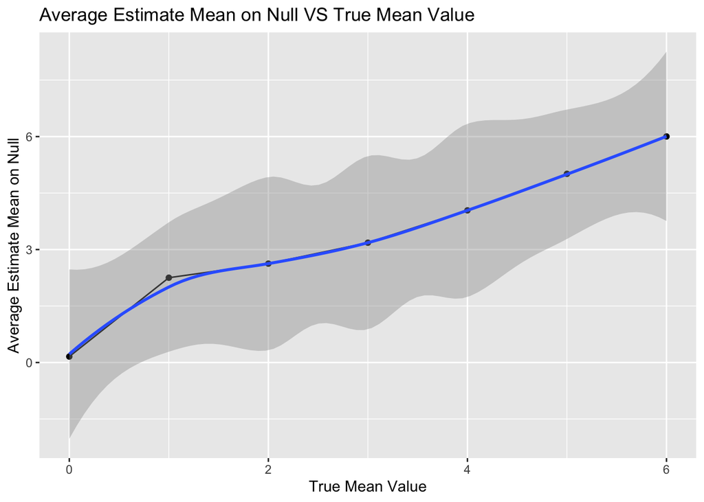

```r
average_null_plot =
  average_null_df |>
  ggplot(aes(x = mu, y = average_estimate_null)) +
  geom_point() +
  geom_line() +
  geom_smooth() +
  labs(
    title = 'Average Estimate Mean on Null VS True Mean Value',
    x = 'True Mean Value',
    y = 'Average Estimate Mean on Null'
  )

average_null_plot
```

Comment: the average null plot shows a relative positive relationship while there is some differences between this graph to the last graph from 0 to 1 that the slope is higher from 0 to 1 and it decreases after true mean value of 1. the later trend is similar.

Is the sample average of μ̂ across tests for which the null is rejected approximately equal to the true value of μ? Why or why not?

No, the average estimates plot shows the average estimate of μ is approximately equal to the true value of mean. However, the average estimate of μ̂ only in samples for which the null was rejected have some difference with the true value fou wWhen the true value of mu is closer to the null hypothesis, the test may not have enough power to reject the null hypothesis, leading to a biased sample of estimates. The power of the test increases, when the true mean increases, so it is more likely to reject the null hypothesis when it is false.